# Untitled

"

7/18/2021

importing libraries

```r
require(tidyverse)
```

```r
require(ggplot2)
require(ggthemes)
require(hrbrthemes)
require(magrittr)
```

importing data in to r

```r
library(readr)
my_data_new <- read_csv("clean_data.csv")
View(my_data_new)
```

TREND IN DIFFERENT COLUMNS

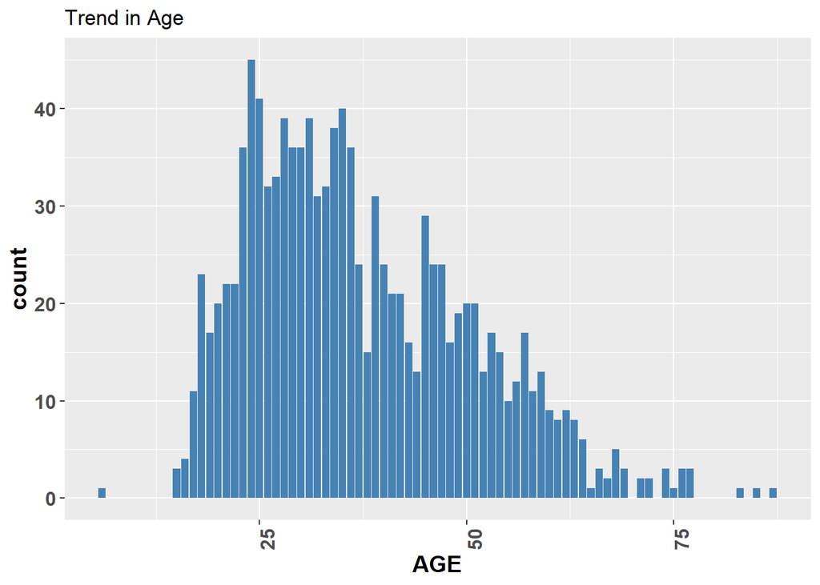

```r
my_data_new %>% ggplot(aes(age))+
  geom_bar(fill = 'steelblue')+
  labs(x='AGE', Y='Value Count', title = 'Trend in Age')+
  theme(axis.title = element_text(size = 12),
        axis.title.x = element_text(face = 'bold', size = 14),
        axis.title.y = element_text(face = 'bold', size = 14),
        axis.text.x = element_text(face = 'bold', size = 12, angle = 90),
        axis.text.y = element_text(face = 'bold', size = 12))+
  scale_fill_brewer(palette = 'set1')
```

The most affected age bracket lies between 23-35

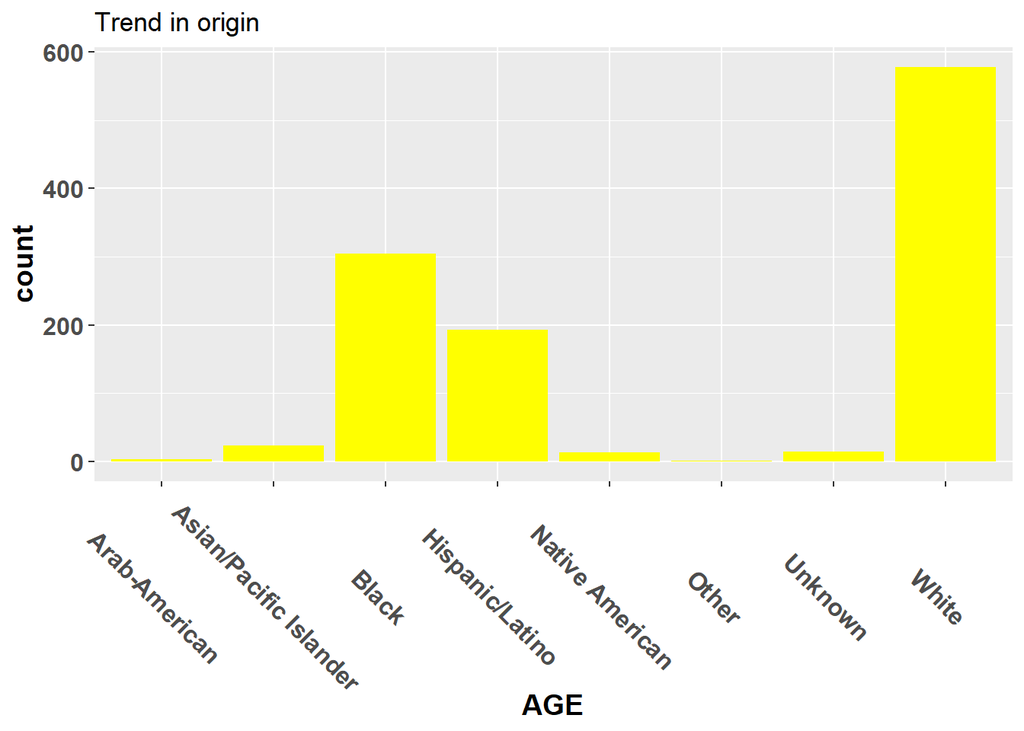

```r
#
my_data_new %>% ggplot(aes(origin))+
  geom_bar(fill = 'yellow')+
  labs(x='AGE', Y='Value Count', title = 'Trend in origin')+
  theme(axis.title = element_text(size = 12),
        axis.title.x = element_text(face = 'bold', size = 14),
        axis.title.y = element_text(face = 'bold', size = 14),
        axis.text.x = element_text(face = 'bold', size = 12, angle = -45),
        axis.text.y = element_text(face = 'bold', size = 12))+
  scale_fill_brewer(palette = 'set1')
```

The most affected origin is white ,followed by black, then the latinos

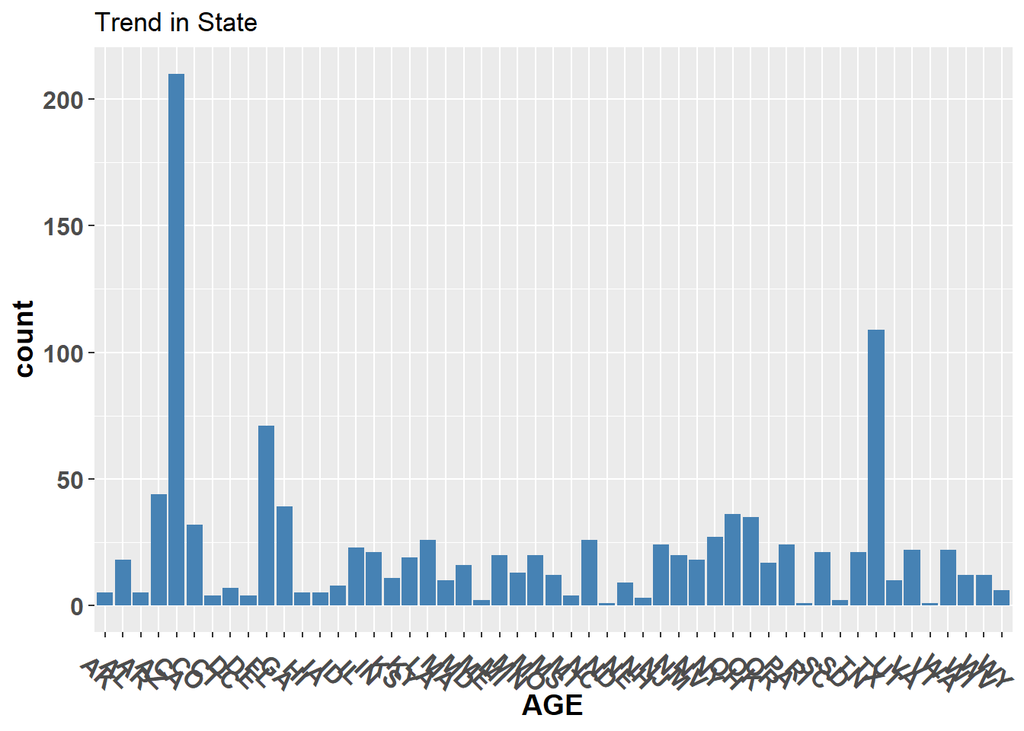

```r
#
my_data_new %>% ggplot(aes(state))+
  geom_bar(fill = 'steelblue')+
  labs(x='AGE', Y='Value Count', title = 'Trend in State')+
  theme(axis.title = element_text(size = 12),
        axis.title.x = element_text(face = 'bold', size = 14),
        axis.title.y = element_text(face = 'bold', size = 14),
        axis.text.x = element_text(face = 'bold', size = 12, angle = -45),
        axis.text.y = element_text(face = 'bold', size = 12))+
  scale_fill_brewer(palette = 'set1')
```

the most affected states are california,texas and florida

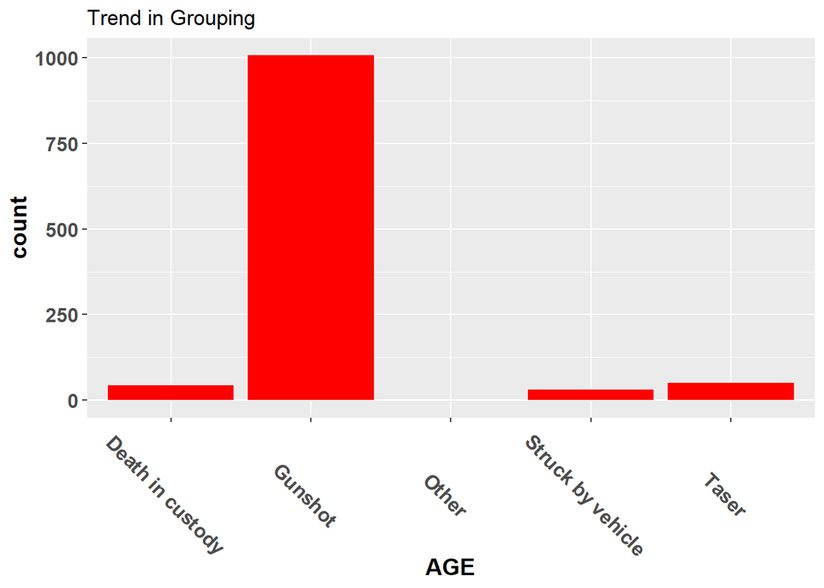

```r
#
my_data_new %>% ggplot(aes(grouping))+
  geom_bar(fill = 'red')+
  labs(x='AGE', Y='Value Count', title = 'Trend in Grouping')+
  theme(axis.title = element_text(size = 12),
        axis.title.x = element_text(face = 'bold', size = 14),
        axis.title.y = element_text(face = 'bold', size = 14),
        axis.text.x = element_text(face = 'bold', size = 12, angle = -45),
        axis.text.y = element_text(face = 'bold', size = 12))+
  scale_fill_brewer(palette = 'set1')
```

the most used weapon is guns

FACET WRAPPING ORIGIN AND GROUPING

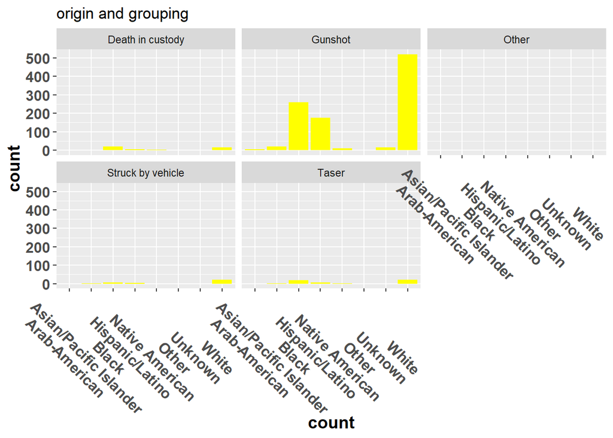

```r
#
my_data_new %>% ggplot(aes(origin))+
  geom_bar(fill = 'yellow')+
  facet_wrap(~grouping)+
  labs(x='count', Y='', title = 'origin and grouping')+
  theme(axis.title = element_text(size = 12),
        axis.title.x = element_text(face = 'bold', size = 14),
        axis.title.y = element_text(face = 'bold', size = 14),
        axis.text.x = element_text(face = 'bold', size = 12, angle = -45),
        axis.text.y = element_text(face = 'bold', size = 12))+
  scale_fill_brewer(palette = 'set1')
```

PLOTTING SOME USEFULL VISUALIZATIONS

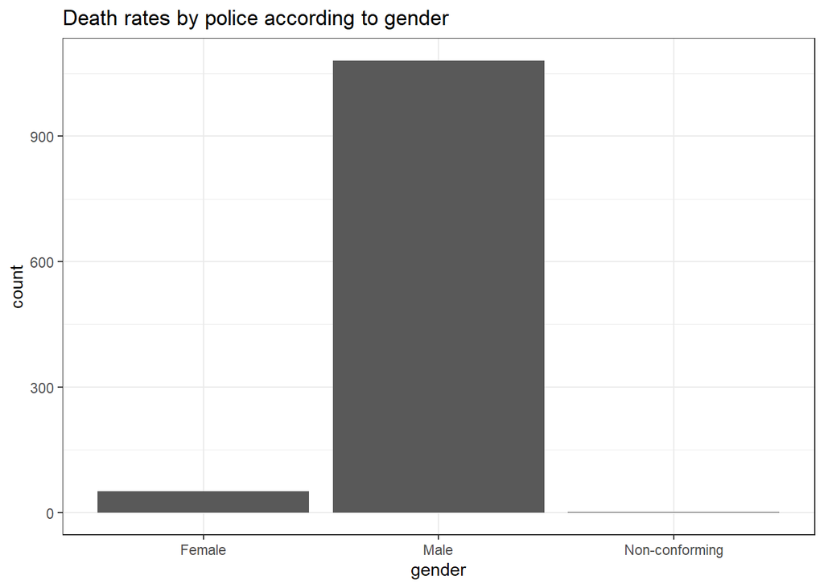

```r
my_data_new %>% ggplot(aes(gender)) + geom_bar()+theme_bw() +labs(title = "Death rates by police according to gender")
```

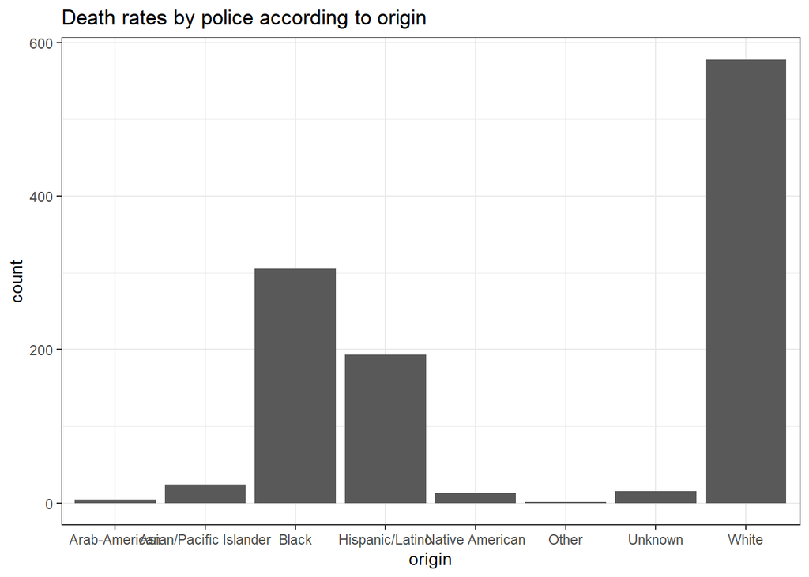

```r
my_data_new %>% ggplot(aes(origin)) + geom_bar()+theme_bw() +labs(title = "Death rates by police according to origin")
```

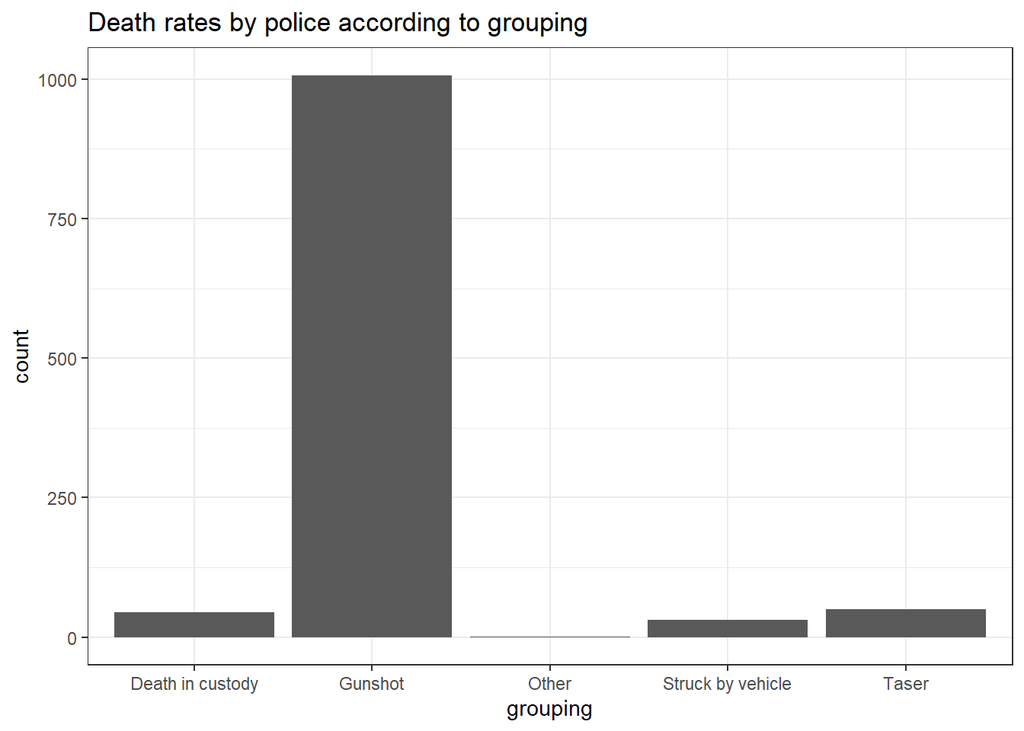

```r
my_data_new %>% ggplot(aes(grouping)) + geom_bar()+theme_bw() +labs(title = "Death rates by police according to grouping")
```

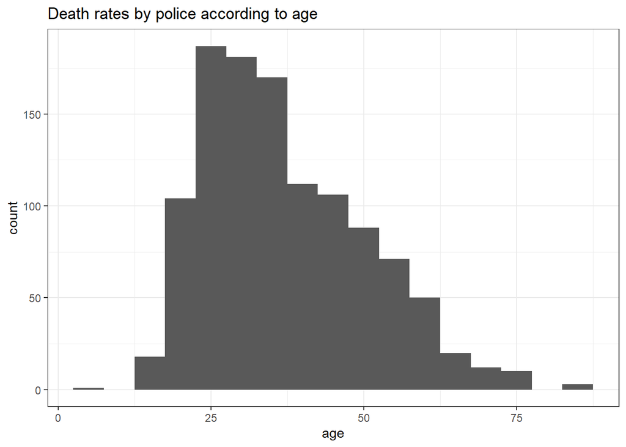

```r
my_data_new %>% ggplot(aes(age)) + geom_histogram(binwidth = 5)+theme_bw() +labs(title = "Death rates by police according to age")
```

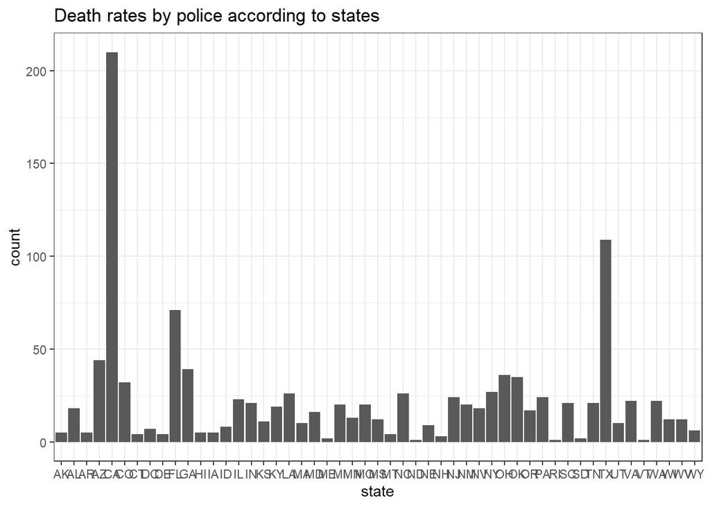

```r
my_data_new %>% ggplot(aes(state)) + geom_bar()+theme_bw() +labs(title = "Death rates by police according to states")
```

RELATING TWO VARIABLES

we can compare two variables using a the libary ggplot.we can use a geom_count as follows

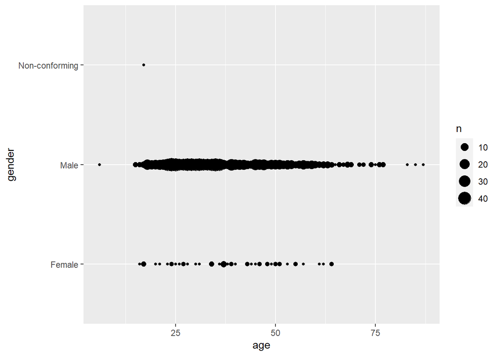

```r
my_data_new%>%ggplot(aes(age, gender)) + geom_count()
```

PLOTTING A SCATTERPLOT

using the plot function we create a scatterplot output as follows

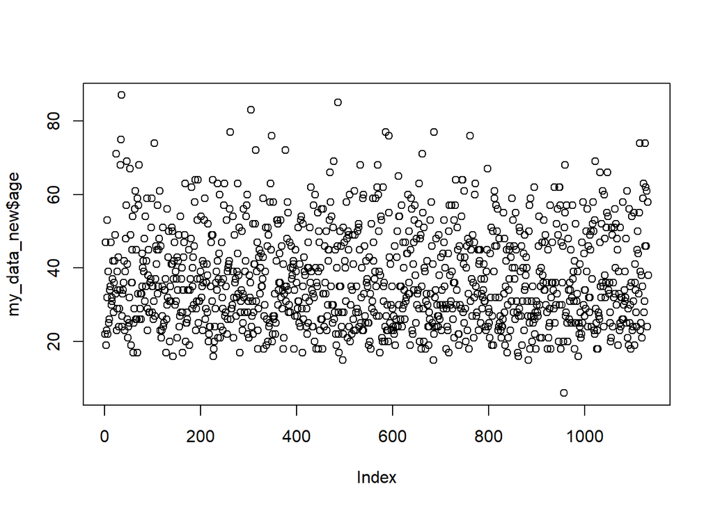

```r
plot(my_data_new$age)
```

TIME SERIES

we create a new column that involves date that we will use to plot a time series

The codes below generates the new column that we will be using to plot the time series

```r
x=my_data_new %>%
  mutate(age=as.numeric(age),
         month_int=recode(my_data_new$month,
                          "January"=1, "February"=2, "March"=3, "April"=4, "May"=5,
                          "June"=6, "July"=7, "August"=8, "September"=9, "October"=10,
                          "November"=11, "December"=12),
         date = strptime(as.factor(paste(month_int, day, year, sep= "/")),format="%m/%d/%Y"),
         date_conv = as.Date(date, "%m/%d/%y"))
```

TIME SERIES PLOT

using the library ggplot we create a time series output as follows

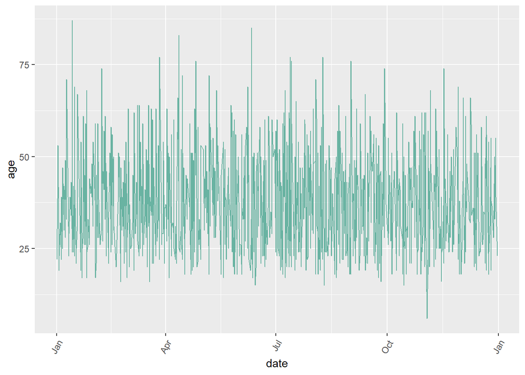

```r
#
ggplot(x, aes(x=date_conv, y=age)) +
  geom_line(color="#69b3a2") +
  labs(x="date",y="age", tittle="time series plot")+
  scale_x_date(date_labels = "%b")+
  theme(axis.text.x=element_text(angle=60, hjust=1))
```

QPLOT

using the library ggplot we create a qplot

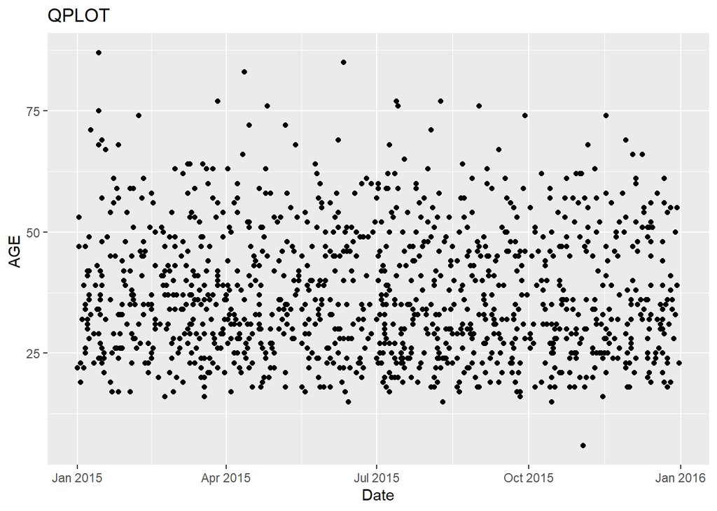

```r
#
qplot(x=date_conv, y=age,
      data=x, na.rm=TRUE,
      main="QPLOT ",
      xlab="Date", ylab="AGE ")
```